# 관광두레 주민공동체 현황분석

한림대학교 이기원

## 자료 구조

### 기초자료

```
## 'data.frame':    97 obs. of  24 variables:
##  $ 조직명      : chr  "수원누리" "수원화성공예_협" "행궁맛촌" "이웃문화협동조합" ...
##  $ 시도        : Factor w/ 8 levels "강원","경기",..: 2 2 2 2 2 2 2 2 2 2 ...
##  $ 시군        : chr  "수원" "수원" "수원" "수원" ...
##  $ PD.1        : chr  "김용균" "김용균" "김용균" "김용균" ...
##  $ PD.2        : chr  "박호철" "박호철" "박호철" "박호철" ...
##  $ 공동체상태  : chr  "창업준비" "창업준비" "창업준비" "경영개선" ...
##  $ 조직형태    : chr  "임의단체" "임의단체" "임의단체" "법인" ...
##  $ 조직원      : num  4 4 4 5 5 5 40 67 5 5 ...
##  $ 법인유형    : chr  "임의단체" "임의단체" "임의단체" "협동조합" ...
##  $ 설립일      : POSIXct, format: "2014-05-01" "2015-03-01" ...
##  $ 사업자등록  : chr  "NA" "513-80-29465" "NA" "124-87-43816" ...
##  $ 업태        : chr  "NA" "NA" "NA" "서비스" ...
##  $ 종목        : chr  "NA" "NA" "NA" "문화기획" ...
##  $ 소재지      : chr  "수원" "수원" "수원" "수원" ...
##  $ 인적자원    : chr  "하" "중" "중" "상" ...
##  $ 물적자원    : chr  "중" "중" "중" "중" ...
##  $ 재무자원    : chr  "하" "하" "하" "중" ...
##  $ 정부지원사업: num  1 1 1 1 0 0 0 0 0 0 ...
##  $ 사업명      : chr  "성안에서놀자" "성안에서놀자" "경기도특화거리지원" "수원시마을만들기" ...
##  $ 지원금.천원.: num  12000 12000 10000 5000 0 0 0 0 0 0 ...
##  $ 지원사항    : chr  "SW+HW" "SW+HW" "HW" "SW" ...
##  $ 사업아이템  : chr  "관광기념품" "관광기념품" "식음" "체험" ...
##  $ 아이디어    : chr  "상품" "쇼핑몰" "간식" "해당없음" ...
##  $ 대표상품    : chr  "해당없음" "해당없음" "해당없음" "체험패키지" ...
```

### 성과자료

```
## 'data.frame':    97 obs. of  30 variables:
##  $ 방문객_2012           : num  0 0 0 0 0 ...
##  $ 방문객_2013           : num  0 0 0 5000 0 0 0 0 0 0 ...
##  $ 방문객_2014           : num  0 0 0 4000 0 ...
##  $ 매출_2012             : num  0 0 0 0 0 0 653000 0 0 0 ...
##  $ 매출_2013             : num  0 0 0 80000 0 0 0 0 0 0 ...
##  $ 매출_2014             : num  0 0 0 70000 0 ...
##  $ 성과_법인화           : chr  "No" "No" "No" "Yes" ...
##  $ 성과_사업착수         : chr  "No" "No" "Yes" "Yes" ...
##  $ 성과_사업자등록       : chr  "No" "Yes" "No" "Yes" ...
##  $ 성과_상품개발         : chr  "No" "No" "No" "Yes" ...
##  $ 성과_기술개발         : chr  "No" "No" "No" "Yes" ...
##  $ 성과_신기술개발       : chr  "No" "No" "No" "No" ...
##  $ 성과_신상품개발       : chr  "No" "No" "No" "No" ...
##  $ 성과_사업장확보       : chr  "No" "No" "No" "Yes" ...
```

[output cut: 16 more lines]

## 변수별 기초통계 및 요약

```
## $조직명
##    Length     Class      Mode
##        97 character character
##
## $시도
## 강원 경기 경남 경북 전남 전북 충남 충북
##   10   13   11   18   17   18    2    8
##
## $시군
##    Length     Class      Mode
##        97 character character
##
## $PD.1
##    Length     Class      Mode
##        97 character character
##
## $PD.2
##    Length     Class      Mode
##        97 character character
##
## $공동체상태
##    Length     Class      Mode
##        97 character character
##
## $조직형태
##    Length     Class      Mode
##        97 character character
##
## $조직원
##    Min. 1st Qu.  Median    Mean 3rd Qu.    Max.
##     3.0     5.0     7.0    13.9    12.0   162.0
##
## $법인유형
##    Length     Class      Mode
##        97 character character
##
## $인적자원
##    Length     Class      Mode
##        97 character character
##
## $물적자원
##    Length     Class      Mode
##        97 character character
##
## $재무자원
##    Length     Class      Mode
##        97 character character
```

```
## $정부지원사업
##    Min. 1st Qu.  Median    Mean 3rd Qu.    Max.
##    0.00    0.00    0.00    0.67    1.00    8.00
##
## $지원금.천원.
##    Min. 1st Qu.  Median    Mean 3rd Qu.    Max.
##       0       0       0  420217   80000 7000000
##
## $지원사항
##    Length     Class      Mode
##        97 character character
##
## $사업아이템
##    Length     Class      Mode
##        97 character character
##
## $방문객_2012
##    Min. 1st Qu.  Median    Mean 3rd Qu.    Max.
##       0       0       0    8338       0  650000
##
## $방문객_2013
##    Min. 1st Qu.  Median    Mean 3rd Qu.    Max.
##       0       0       0    8738       0  700000
##
## $방문객_2014
##    Min. 1st Qu.  Median    Mean 3rd Qu.    Max.
##   0e+00   0e+00   0e+00   1e+04   7e+02   8e+05
##
## $매출_2012
##    Min. 1st Qu.  Median    Mean 3rd Qu.    Max.
##       0       0       0   25420       0  680000
##
## $매출_2013
##    Min. 1st Qu.  Median    Mean 3rd Qu.    Max.
##       0       0       0   23269       0  910000
##
## $매출_2014
##    Min. 1st Qu.  Median    Mean 3rd Qu.    Max.
##       0       0       0   27483    5400  700000
##
```

[output cut: 80 more lines]

```
## $사업실적_멘토링
##    Min. 1st Qu.  Median    Mean 3rd Qu.    Max.
##   0.000   0.000   0.000   0.196   0.000   3.000
##
## $사업실적_파일럿
##    Min. 1st Qu.  Median    Mean 3rd Qu.    Max.
##    0.00    0.00    0.00    0.56    0.00    6.00
##
## $사업실적_관광공사
##    Min. 1st Qu.  Median    Mean 3rd Qu.    Max.
##   0.000   0.000   0.000   0.361   0.000   3.000
##
## $기타
##    Min. 1st Qu.  Median    Mean 3rd Qu.    Max.
##    0.00    0.00    0.00    0.91    2.00    6.00
```

# 교차분석

## 공동체상태와 조직형태

### 교차표

ㅇ공동체상태와 조직형태(계)

|  | 법인 | 임의단체 | 계 |
| --- | --- | --- | --- |
| 경영개선 | 24 | 3 | 27 |
| 창업준비 | 28 | 42 | 70 |
| 계 | 52 | 45 | 97 |

ㅇ공동체상태와 조직형태(%, 계)

|  | 법인 | 임의단체 | 계 |
| --- | --- | --- | --- |
| 경영개선 | 88.9 | 11.1 | 100 |
| 창업준비 | 40.0 | 60.0 | 100 |

ㅇ조직형태와 공동체상태(%, 계)

|  | 법인 | 임의단체 |
| --- | --- | --- |
| 경영개선 | 46.2 | 6.67 |
| 창업준비 | 53.8 | 93.33 |
| 계 | 100.0 | 100.00 |

### 모자이크 플롯

- 공동체상태와 조직형태
  - 경영개선 상태에서 법인격을 갖춘 공동체사업의 비율이 창업준비 상태에서 법인격을 갖춘 공동체사업의 비율보다 압도적으로 많다는 점에 유의.

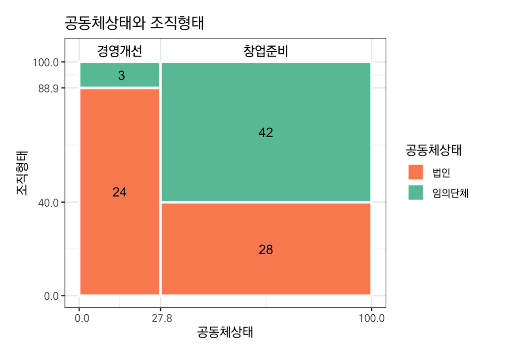

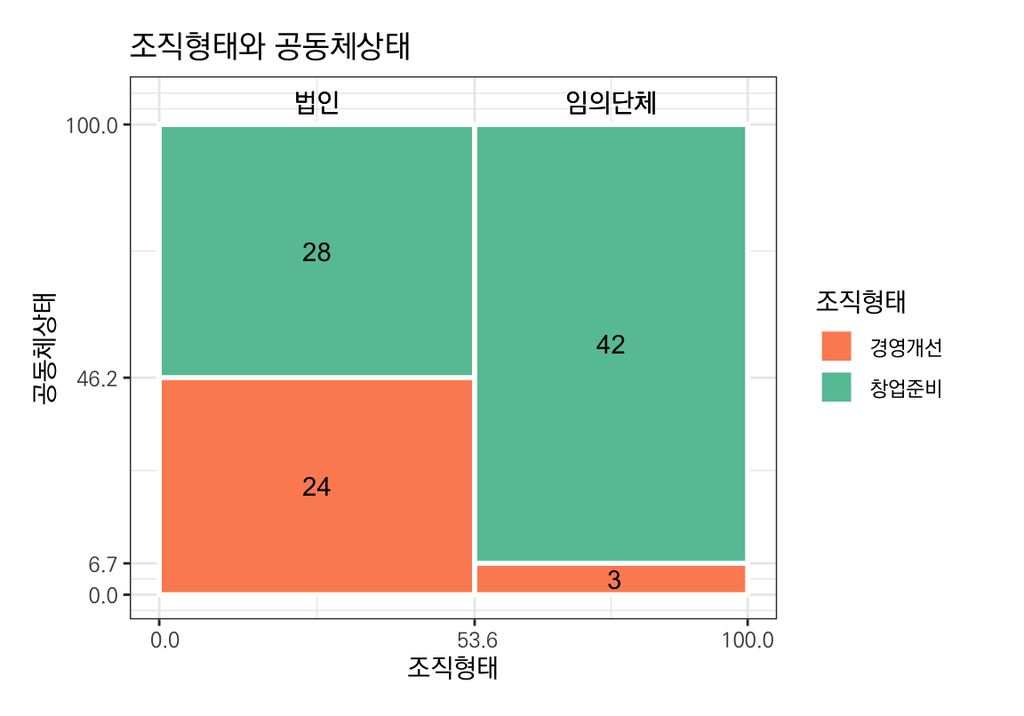

## 성장단계 구분에의 시사점

- 경영개선 상태의 법인 조직
  - 모두 사업에 착수하였고, 사업자등록도 마침. 매출도 대부분 발생

[output not shown]

- 경영개선 상태의 임의단체 조직
  - 임의단체인 경우가 소수 있으나 모두 사업에 착수하였고, 사업자등록도 마침. 모두 매출 발생

[output not shown]

- 창업준비 상태의 법인 조직
  - 사업미착수는 39%, 사업자미등록이 32%에 달함. 매출 극히 일부 발생.

[output not shown]

- 창업준비 상태의 임의단체 조직
  - 대부분 사업미착수(83%)이고, 사업자미등록(93%)인 상태임. 매출 극히 일부에서 발생하는 것으로 보고하고 있으나 개인사업자 명의의 실적임.

[output not shown]

### 3원 교차분석

* 공동체상태/조직형태와 사업자등록여부(%)

|  | 등록 | 미등록 |
| --- | --- | --- |
| 경영개선_법인 | 100.0 | 0.0 |
| 경영개선_임의단체 | 100.0 | 0.0 |
| 창업준비_법인 | 67.9 | 32.1 |
| 창업준비_임의단체 | 7.1 | 92.9 |

* 공동체상태/조직형태와 사업착수여부

|  | 착수 | 미착수 |
| --- | --- | --- |
| 경영개선_법인 | 24 | 0 |
| 경영개선_임의단체 | 3 | 0 |
| 창업준비_법인 | 17 | 11 |
| 창업준비_임의단체 | 7 | 35 |

* 공동체상태/조직형태와 사업착수여부(%)

|  | 착수 | 미착수 |
| --- | --- | --- |
| 경영개선_법인 | 100.0 | 0.0 |
| 경영개선_임의단체 | 100.0 | 0.0 |
| 창업준비_법인 | 60.7 | 39.3 |
| 창업준비_임의단체 | 16.7 | 83.3 |

## 공동체상태와 법인유형

### 교차표

<공동체상태와 조직유형>

|  | 마을회 | 사단법인 | 영농조합법인 | 유한회사 | 임의단체 | 주식회사 | 협동조합 |
| --- | --- | --- | --- | --- | --- | --- | --- |
| 경영개선 | 1 | 2 | 13 | 1 | 2 | 3 | 5 |
| 창업준비 | 0 | 3 | 9 | 0 | 42 | 2 | 14 |

<주식회사인 공동체사업체>

|  | 공동체상태 | 조직명 |
| --- | --- | --- |
| 22 | 경영개선 | 아름다운인제관광 |
| 30 | 경영개선 | 제천수상레저 |
| 42 | 창업준비 | 벽골제마을주식회사 |
| 56 | 창업준비 | 동고지명품마을 |
| 59 | 경영개선 | 에코도시락 |

### 모자이크 플롯

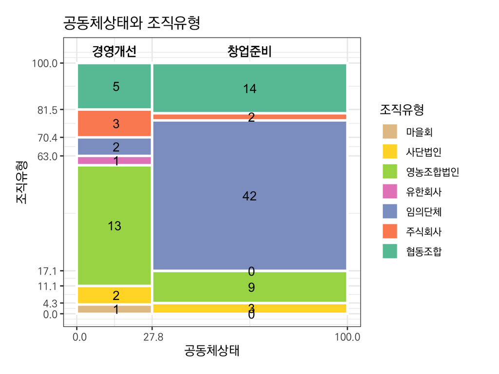

## 공동체상태와 사업아이템

### 교차표(개소수)

- 경영개선 상태에서는 ‘식음’과 ’체험’, 창업준비 상태에서는 ’식음’과 ’관광기념품’이 많이 있음.

<공동체상태와 사업아이템>

|  | 관광기념품 | 교통 | 레저스포츠 | 숙박 | 식음 | 주민여행사 | 체험 | 계 |
| --- | --- | --- | --- | --- | --- | --- | --- | --- |
| 경영개선 | 1 | 0 | 4 | 1 | 10 | 2 | 9 | 27 |
| 창업준비 | 13 | 1 | 4 | 10 | 20 | 10 | 12 | 70 |

### 교차표(%)

- 창업준비 상태에서 ’관광기념품’의 비중이 매우 높음.

<공동체상태와 사업아이템(%)>

|  | 관광기념품 | 교통 | 레저스포츠 | 숙박 | 식음 | 주민여행사 | 체험 | 계 |
| --- | --- | --- | --- | --- | --- | --- | --- | --- |
| 경영개선 | 3.7 | 0.0 | 14.8 | 3.7 | 37.0 | 7.4 | 33.3 | 100 |
| 창업준비 | 18.6 | 1.4 | 5.7 | 14.3 | 28.6 | 14.3 | 17.1 | 100 |

### 모자이크 플롯

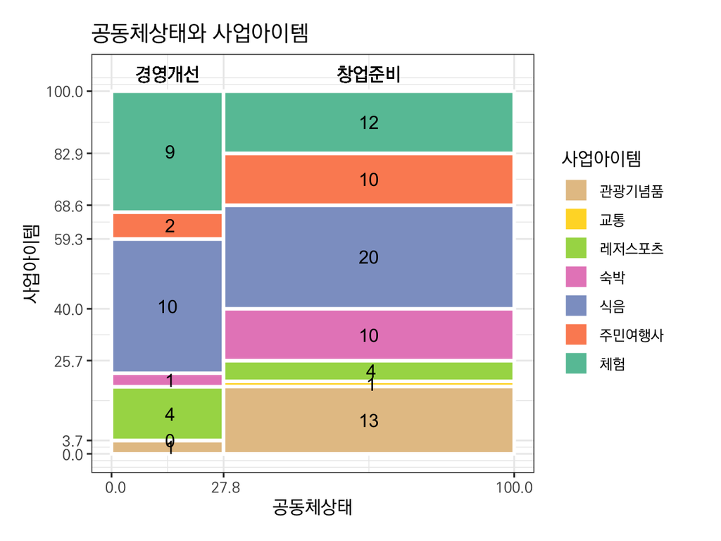

## 공동체상태와 업력

### 요약표

```
## $경영개선
##    Min. 1st Qu.  Median    Mean 3rd Qu.    Max.
##    1.30    2.55    4.50    4.91    6.15   12.40
##
## $창업준비
##    Min. 1st Qu.  Median    Mean 3rd Qu.    Max.
##    0.10    0.92    1.40    1.62    1.60   11.70
```

### Box Plot

- 공동체 상태별 5숫자 요약 및 이상점 파악
  - ’아름다운인제관광’과 ’예그리나’가 예외적으로 오랜 업력

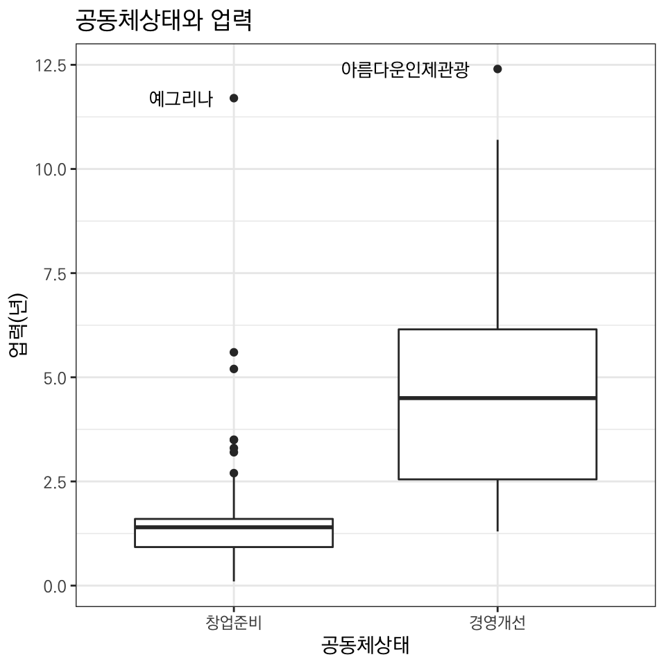

### ECDF

- 분위수 비교 뿐 아니라 평균 업력 비교도 가능함

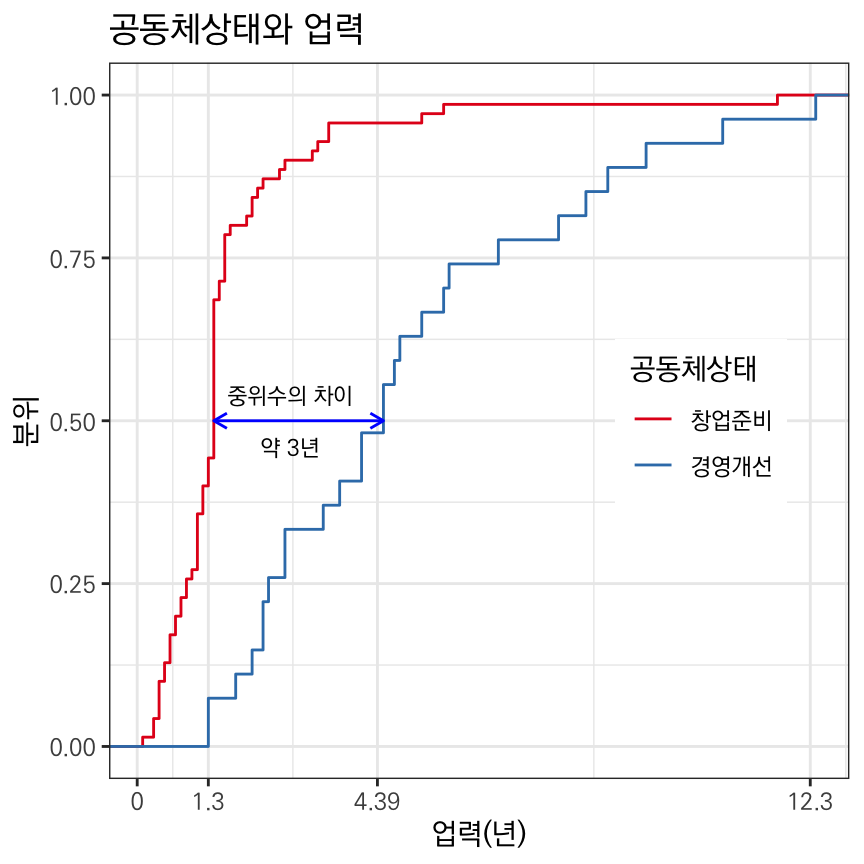

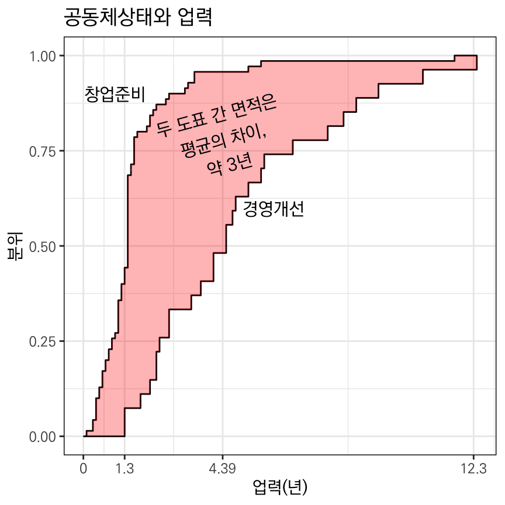

### Dot Chart

- 전체 주민공동체사업의 업력을 공동체상태별로 한눈에 비교
  - 개별 조직명도 파악됨.

[figure not shown]

[figure not shown]

[figure not shown]

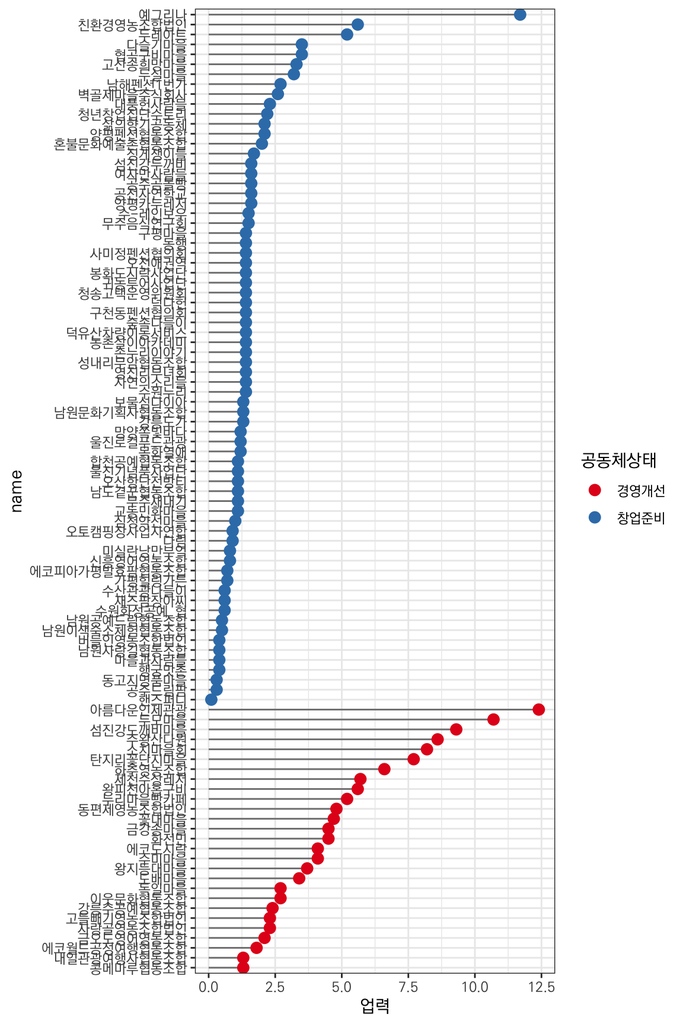

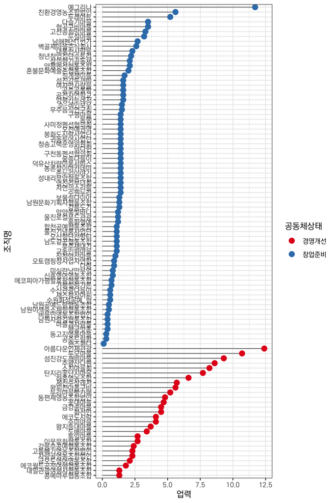

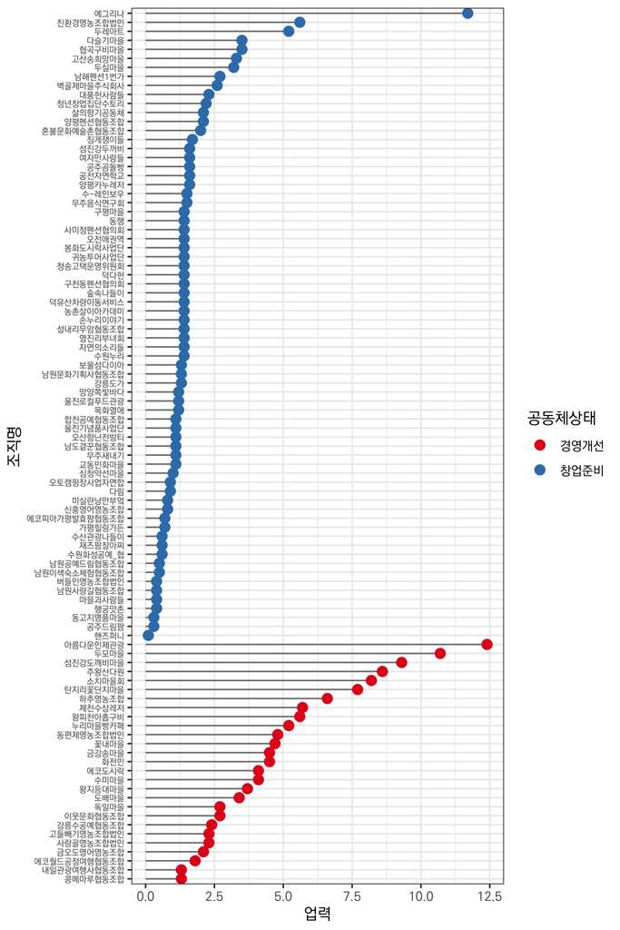

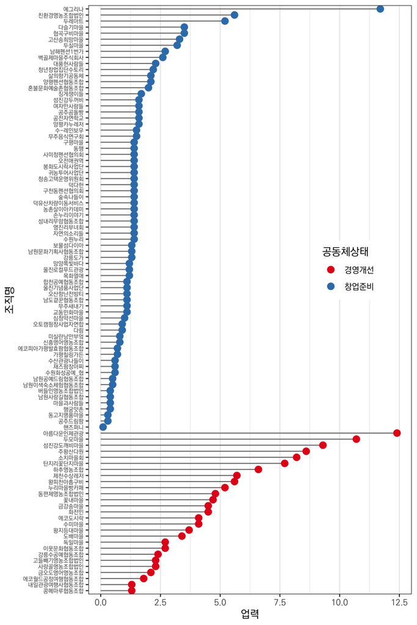

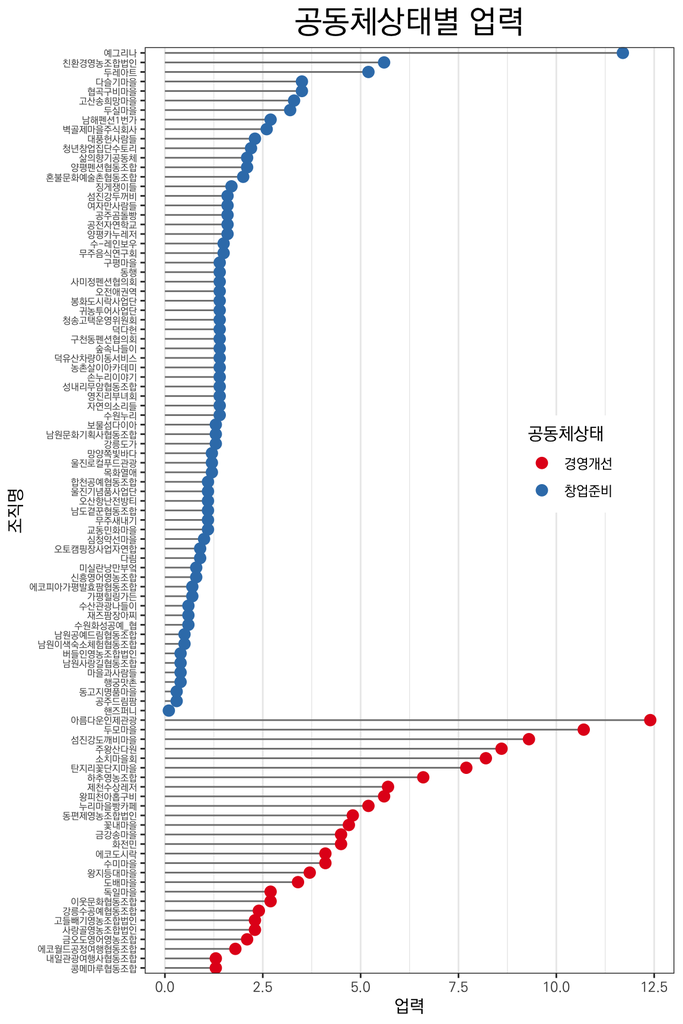

## 방문객과 매출 요약

### 공동체상태별 평균 비교

[output not shown]

### 공동체상태별 중위수 비교

[output not shown]

## 방문객 및 매출 상위 조직

### 방문객(2014)

| 공동체상태 | 조직명 | 방문객(2014) |
| --- | --- | --- |
| 경영개선 | 독일마을 | 800000 |
| 경영개선 | 에코도시락 | 28000 |
| 경영개선 | 금강송마을 | 17000 |
| 경영개선 | 아름다운인제관광 | 15000 |
| 경영개선 | 두모마을 | 13896 |
| 경영개선 | 수미마을 | 10560 |
| 경영개선 | 누리마을빵카페 | 8220 |
| 경영개선 | 하추영농조합 | 7234 |
| 경영개선 | 왕지등대마을 | 6511 |
| 경영개선 | 강릉수공예협동조합 | 6050 |
| 경영개선 | 꽃내마을 | 5800 |
| 창업준비 | 공전자연학교 | 5460 |
| 창업준비 | 청송고택운영위원회 | 5384 |
| 경영개선 | 화전민 | 5000 |
| 경영개선 | 주왕산다원 | 3800 |
| 경영개선 | 콩메마루협동조합 | 3477 |
| 경영개선 | 제천수상레저 | 3400 |
| 경영개선 | 소치마을회 | 3358 |
| 경영개선 | 탄지리꽃단지마을 | 3154 |
| 경영개선 | 왕피천아홉구비 | 3000 |

### 방문객(2015, 3개월)

| 공동체상태 | 조직명 | 방문객(2015, 3개월) |
| --- | --- | --- |
| 경영개선 | 두모마을 | 10154 |
| 경영개선 | 왕지등대마을 | 8300 |
| 경영개선 | 섬진강도깨비마을 | 7609 |
| 경영개선 | 내일관광여행사협동조합 | 6600 |
| 창업준비 | 행궁맛촌 | 5200 |
| 창업준비 | 남원사랑길협동조합 | 2950 |
| 창업준비 | 숲속나들이 | 2210 |
| 경영개선 | 누리마을빵카페 | 2100 |
| 경영개선 | 에코월드공정여행협동조합 | 2095 |
| 경영개선 | 하추영농조합 | 1823 |
| 창업준비 | 성내리무암협동조합 | 1300 |
| 창업준비 | 공전자연학교 | 1200 |
| 경영개선 | 왕피천아홉구비 | 1200 |
| 경영개선 | 주왕산다원 | 1170 |
| 창업준비 | 무주새내기 | 1120 |
| 창업준비 | 남원이색숙소체험협동조합 | 1100 |
| 경영개선 | 동편제영농조합법인 | 1100 |
| 창업준비 | 교동민화마을 | 1080 |
| 경영개선 | 아름다운인제관광 | 1000 |
| 경영개선 | 금강송마을 | 1000 |

### 매출(2014)

[output not shown]

### 매출(2015, 3개월)

[output not shown]

### 자료 갈무리

```r
doorae0928 <- doorae
save.image("doorae_new.RData")
```